# Malaria Risk Prediction in Kenya using Artificial Intelligence (AI) & Machine Learning(ML) Models

D.K.Muriithi

Chuka University, Kenya

2025-08-05

# Set a working directory

This is a default location where R looks for files and saves outputs

```r
setwd("~/2025-AMMnet_Malaria_Modeling_Workshop")
```

# Install and load necessary libraries

**Loading libraries**

```r
library(caret)         ## for training machine learning models
library(psych)         ## for description of  data
library(ggplot2)       ## for data visualization
library(caretEnsemble) ## enables the creation of ensemble models
library(tidyverse)     ## for data manipulation
library(mlbench)       ## for benchmarking ML Models
library(flextable)     ## to create and style tables
library(mltools)       ## for hyperparameter tuning
library(tictoc)        ## for determining the time taken for a model to run
library(ROSE)          ## for random oversampling
library(smotefamily)   ## for smote sampling
library(ROCR)          ## for ROC curve
library(pROC)          ## for visualizing, smoothing, and comparing ROC curves
library(e1071)         ## for statistical modeling and  machine learning tasks(SVM)
library(class)         ## for classification using k-Nearest Neighbors and other methods
library(caTools)       ## for splitting data into training and testing sets
library(MASS)          ## provides plotting functions and datasets
library(ISLR)          ## for practical applications of statistical learning methods
library(boot)          ## useful for performing bootstrap resampling
library(cvTools)       ## contains functions for cross-validation, bootstrapping, & other resampling methods
library(iml)           ## provide tools to analyze and interpret machine learning models
library(lime)          ## powerful tools for interpreting machine learning models
library(DALEX)         ## powerful tool for interpreting machine learning models.
library(rio)           ## for easy data import, export(saving) and conversion
library(esquisse)      ## GUI tool that allows users to easily create ggplot2 plots interactively
```

# Load and prepare data/Exporatory of the dataset

```r
library(rio) ## for easy data import, export(saving) and conversion

data = import("Malaria Dataset.csv")


#head(data)          # for the 1st few rows in the dataset
#tail(data)          # for the last few rows in the dataset
```

# Exploratory Data Analysis (EDA)

Before we start visualizing our data, we need to understand the characteristics of our data. The goal is to get an idea of the data structure and to understand the relationships between variables.

Here are some functions that can help us understand the structure of our data:

```r
#dim(data)           # for dimensions of dataset

#summary(data)       # for summary of descriptive statistics
#describe(data)      # for descriptive statistics
```

## Check for data structure

```r
str(data)
```

```
'data.frame':   1000 obs. of  18 variables:
 $ Age             : int  25 49 44 40 24 48 26 27 26 33 ...
 $ Gender          : chr  "Female" "Male" "Male" "Female" ...
 $ Rainfall        : num  218.4 62.3 230.6 145.8 250.8 ...
 $ Temperature     : num  26.1 22.9 31.5 20.5 31 26.9 29.3 29.3 25.8 27.2 ...
 $ Humidity        : num  78.4 54.4 88.3 41.6 49.7 82.9 60.5 84 85 63.3 ...
 $ Endemic_Zone    : chr  "Low risk" "Coastal" "Lake Basin" "Lake Basin" ...
 $ Mosquito_Density: num  66.5 167.7 156.7 72.3 46.1 ...
 $ Fever           : chr  "no" "no" "no" "yes" ...
 $ Chills          : chr  "no" "no" "no" "yes" ...
 $ Headache        : chr  "no" "no" "no" "yes" ...
 $ Nausea          : chr  "yes" "no" "no" "yes" ...
 $ Muscle_Aches    : chr  "yes" "yes" "yes" "yes" ...
 $ Fatigue         : chr  "no" "no" "no" "yes" ...
 $ falciparum      : chr  "no" "no" "yes" "yes" ...
 $ vivax           : chr  "no" "no" "no" "no" ...
 $ malariae        : chr  "no" "no" "yes" "yes" ...
 $ ovale           : chr  "no" "no" "no" "yes" ...
 $ Malaria_Result  : chr  "Negative" "Negative" "Negative" "Positive" ...
```

## Convert all character variables to factors

```r
data[] <- lapply(data, function(x) if(is.character(x)) as.factor(x) else x)
```

## Diagnose the data set

```r
library(gtsummary)    #create publication-ready summary tables for regression models and descriptive statistics
library(flextable)    #Creates highly customizable tables suitable for reporting and publication
library(dlookr)       #Analyzes the structure and quality of the dataset

diagnose(data) |> flextable()
```

| variables | types | missing_count | missing_percent | unique_count | unique_rate |
| --- | --- | --- | --- | --- | --- |
| Age | integer | 0 | 0 | 35 | 0.035 |
| Gender | factor | 0 | 0 | 2 | 0.002 |
| Rainfall | numeric | 0 | 0 | 809 | 0.809 |
| Temperature | numeric | 0 | 0 | 151 | 0.151 |
| Humidity | numeric | 0 | 0 | 480 | 0.480 |
| Endemic_Zone | factor | 0 | 0 | 5 | 0.005 |
| Mosquito_Density | numeric | 0 | 0 | 773 | 0.773 |
| Fever | factor | 0 | 0 | 2 | 0.002 |
| Chills | factor | 0 | 0 | 2 | 0.002 |
| Headache | factor | 0 | 0 | 2 | 0.002 |
| Nausea | factor | 0 | 0 | 2 | 0.002 |
| Muscle_Aches | factor | 0 | 0 | 2 | 0.002 |
| Fatigue | factor | 0 | 0 | 2 | 0.002 |
| falciparum | factor | 0 | 0 | 2 | 0.002 |
| vivax | factor | 0 | 0 | 2 | 0.002 |
| malariae | factor | 0 | 0 | 2 | 0.002 |
| ovale | factor | 0 | 0 | 2 | 0.002 |
| Malaria_Result | factor | 0 | 0 | 2 | 0.002 |

```r
#Explore individual columns/variables
#unique(data$Region)                          # unique values for single column
#table(data$Malaria_Result)                           # frequency for a single column
#table(data$Region, data$Intervention_Type) # frequencies for multiple columns
```

## Check for zero variance predictors:

```r
nzv <- nearZeroVar(data[,-18], saveMetrics = TRUE)
print(nzv)
```

```
                 freqRatio percentUnique zeroVar   nzv
Age               1.025641           3.5   FALSE FALSE
Gender            1.049180           0.2   FALSE FALSE
Rainfall          1.000000          80.9   FALSE FALSE
Temperature       1.000000          15.1   FALSE FALSE
Humidity          1.500000          48.0   FALSE FALSE
Endemic_Zone      1.196203           0.5   FALSE FALSE
Mosquito_Density  1.000000          77.3   FALSE FALSE
Fever             1.631579           0.2   FALSE FALSE
Chills            1.538071           0.2   FALSE FALSE
Headache          1.450980           0.2   FALSE FALSE
Nausea            1.481390           0.2   FALSE FALSE
Muscle_Aches      1.631579           0.2   FALSE FALSE
Fatigue           1.481390           0.2   FALSE FALSE
falciparum        2.533569           0.2   FALSE FALSE
vivax             2.597122           0.2   FALSE FALSE
malariae          2.257329           0.2   FALSE FALSE
ovale             2.424658           0.2   FALSE FALSE
```

```r
##The results above show that there is no feature with zero variance
## Remove nzv

#data <- data[, !nzv$nzv]
#dim(data)
```

## Visualizing the Target Variable (Malaria Test Results)

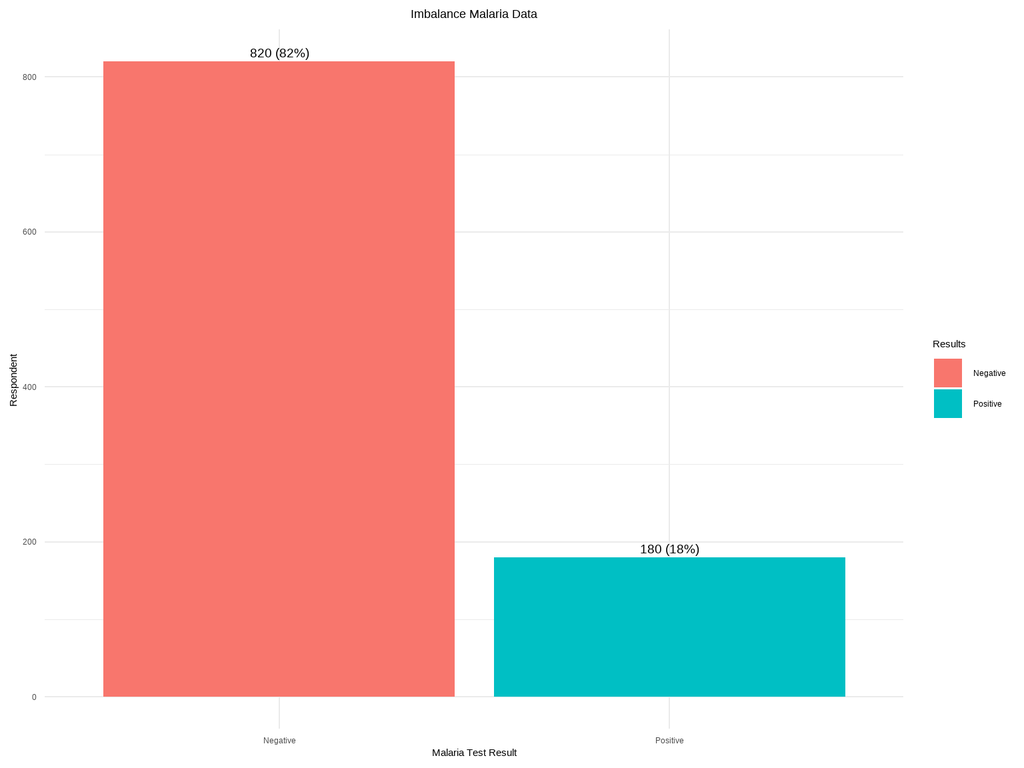

```r
library(ggplot2)       ## for data visualization

# Plot Target variable using ggplot2 function
# Sample dataset
dt <- data.frame(
  Malaria_Result = c("Negative", "Positive"),
  Respondent = c(820, 180)) # Replace with actual numbers

# Calculate percentages
dt1 <- dt %>%
  mutate(Percentage = Respondent / sum(Respondent) * 100)

# Create the bar plot
dt1 |> ggplot(aes(x = Malaria_Result, y = Respondent, fill = Malaria_Result)) +
  geom_bar(stat = "identity", show.legend = TRUE) +
  geom_text(aes(label = paste0(Respondent, " (", round(Percentage, 1), "%)")),vjust = -0.5, size = 5) +
  labs(title = "Imbalance Malaria Data",
       x = "Malaria Test Result",
       y = "Respondent",
       fill = "Results") +
  theme_minimal() +
  theme(plot.title = element_text(hjust = 0.5)) # Align the title to the center
```

# Data Partition for Machine Learning

```r
library(caret)

set.seed(123)

# Create a partition: 75% for training, 25% for testing
index <- createDataPartition(data$Malaria_Result,p = 0.75, list = FALSE)

# Create training and testing sets
train <- data[index, ]
test <- data[-index, ]

# Get the dimensions of your train and test data
dim(train)
```

```
[1] 750  18
```

```r
dim(test)
```

```
[1] 250  18
```

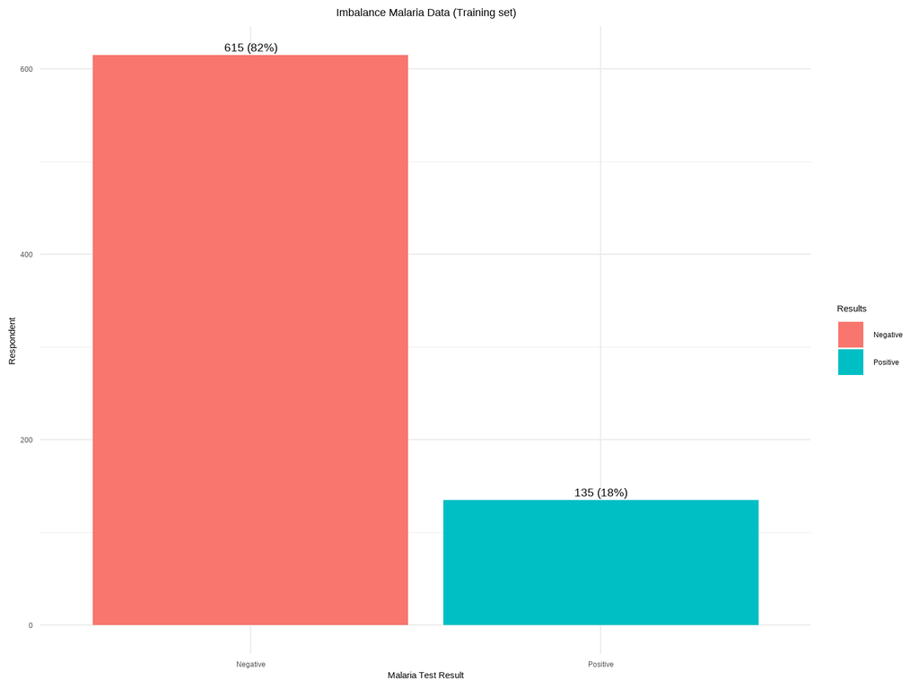

```r
##frequency distribution of classes of the target variable in the train dataset
#table(train$Malaria_Result)
#table(test$Malaria_Result)

# Plot Target variable using ggplot2 function
# Sample dataset
dt1 <- data.frame(
  Malaria_Result = c("Negative", "Positive"),
  Respondent = c(615, 135)) # Replace with actual numbers


# Calculate percentages
dt1 <- dt1 |>
  mutate(Percentage = Respondent / sum(Respondent) * 100)

# Create the bar plot
p1 = dt1 |> ggplot(aes(x = Malaria_Result, y = Respondent, fill = Malaria_Result)) +
  geom_bar(stat = "identity", show.legend = TRUE) +
  geom_text(aes(label = paste0(Respondent, " (", round(Percentage, 1), "%)")),vjust = -0.5, size = 5) +
  labs(title = "Imbalance Malaria Data (Training set)",
       x = "Malaria Test Result",
       y = "Respondent",
       fill = "Results") +
  theme_minimal() +
  theme(plot.title = element_text(hjust = 0.5)) # Align the title to the center
print(p1)
```

# View the models in CARET

```r
models= getModelInfo()
#names(models)
```

# Resampling techinque (Over-sampling)

The minority class is duplicated (synthetically) until both classes have roughly the same number of samples.

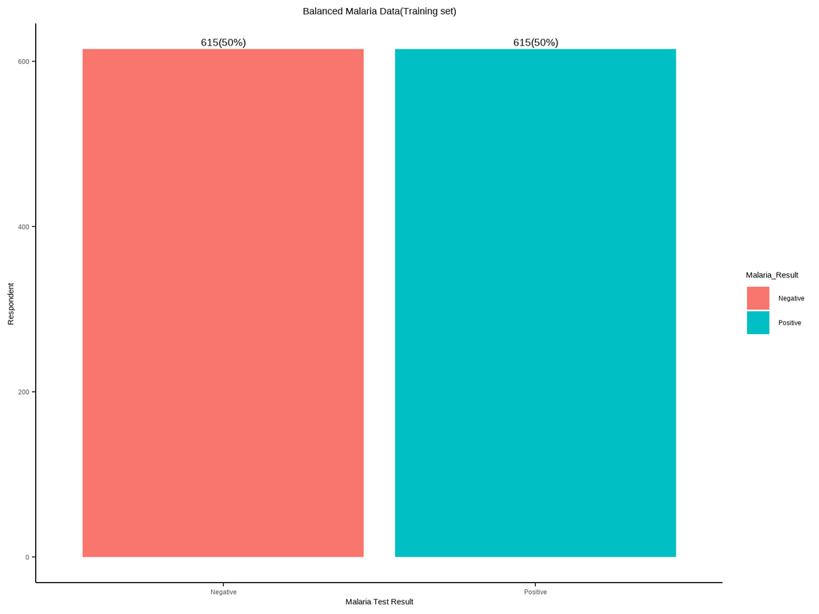

```r
library(ROSE)    ## used for balancing imbalanced datasets (e.g., in binary classification)

set.seed(123)    ## ensures reproducibility: Every time you run this code, you get the same random over-sampling result

over<- ovun.sample(Malaria_Result~., data = train, method = "over", N = 1230 )$data # over-samples the minority class to balance the dataset
# Calculate counts and percentages
over_summary <- over |>
  group_by(Malaria_Result) |>
  summarise(Count = n()) |>
  mutate(Percent = round(Count / sum(Count) * 100, 1))

  # Plot
p2 = ggplot(over, aes(x = Malaria_Result, fill = Malaria_Result)) +
  geom_bar() +
  geom_text(data = over_summary, aes(x = Malaria_Result, y = Count,
             label = paste0(Count, "(", Percent, "%)")),
            vjust = -0.5,     # moves text higher vertically
            hjust = 0.5,      # centers text horizontally
            size = 5) +
labs(title ="Balanced Malaria Data(Training set)",
     y = "Respondent",
     x = "Malaria Test Result") +
  theme_classic() +
  theme(plot.title = element_text(hjust = 0.5)) # Align the title to the center

print(p2)
```

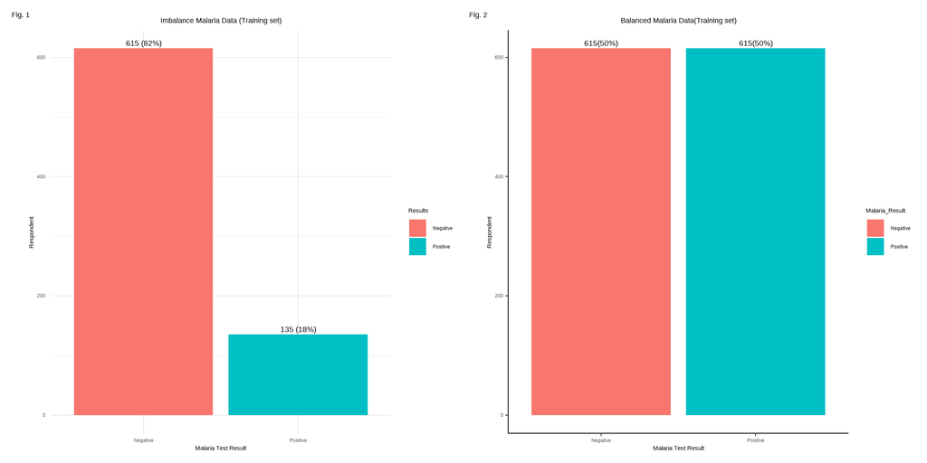

```r
library(patchwork)
library(easystats)

# Display the nested plot
plots(p1, p2, n_columns = 2, tags = paste("Fig.", 1:23))
```

# Cross validation technique

**Cross-validation (CV)** is a resampling technique used to evaluate the performance of a machine learning model and test its ability to generalize to unseen data. The idea is to train and test the model on different subsets of the data to reduce bias and variance in performance estimation. It helps in detecting overfitting and selecting better hyperparameters.

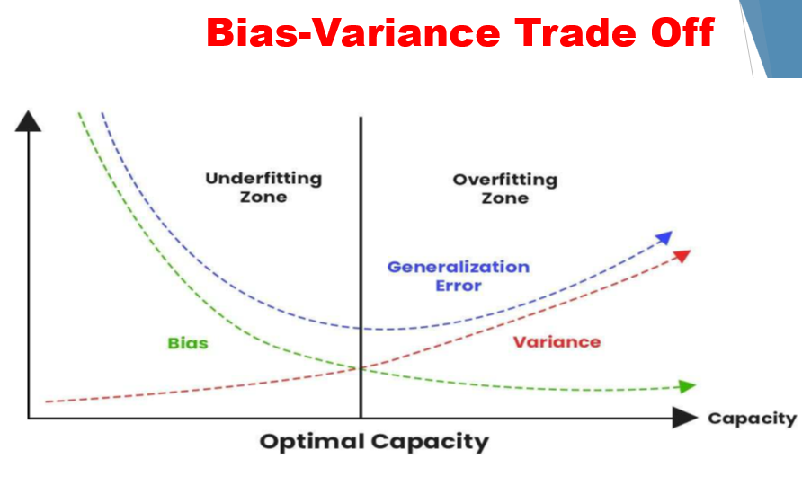

**Two key contributors to model performance are bias and Variance**

**Bias**: We want prediction that are close to the true value of the outcome we arE trying to predict

**Variance:** We want predictions that do not vary too much around the true value

**NB:**A model that performs well on new data will balance these two

**Hyperparameters** are the settings you specify before training a machine learning model. They control the learning process and influence how well the model performs, but they are not learned from the data.

```r
#Creating the train-Control scheme to avoid overfitting & underfitting

library(caret)

control <- trainControl(
  method = "repeatedcv",     # Use repeated cross-validation
  number = 10,               # 10-fold cross-validation
  repeats = 5,               # Repeat the 10-fold CV 5 times
  classProbs = TRUE,         # Compute class probabilities
  summaryFunction = twoClassSummary)  # Use metrics like ROC, Sensitivity, Specificity
```

**method = “repeatedcv”:** This tells caret::train() to use repeated k-fold cross-validation.

**number = 10:** Specifies 10 folds (i.e., 10-fold cross-validation).

**repeats = 5:** The entire 10-fold process will be repeated 5 times, each with a different random split.

**This setup is useful for:**

- Reducing variance in the performance estimate.
- Ensuring the model’s performance is stable across different splits of the data.
- Getting a more reliable estimate of the model’s accuracy, precision, RMSE, or other metrics.

# Train Machine learning Model

# Logistic Regression

```r
# Load libraries
library(caret)               ## for training machine learning models
library(tictoc)              ## for determining the time taken for a model to run

tic()
set.seed(123)                ## Ensures that results are reproducible

LRModel <- train(factor(Malaria_Result) ~ .,
                 data = over,
                 method = "glm",
                 trControl = control)
toc()
```

```
1.47 sec elapsed
```

```r
LRModel
```

```
Generalized Linear Model

1230 samples
  17 predictor
   2 classes: 'Negative', 'Positive'

No pre-processing
Resampling: Cross-Validated (10 fold, repeated 5 times)
Summary of sample sizes: 1106, 1106, 1108, 1107, 1107, 1108, ...
Resampling results:

  ROC        Sens       Spec
  0.9944202  0.9593971  0.9736066
```

```r
# Prediction using Logistic Regression model
LRpred = predict(LRModel,newdata = test)

# Evaluation of the Logistic Regression model performance metrics
LR_CM <- confusionMatrix(LRpred,as.factor(test$Malaria_Result), positive = "Positive", mode='everything')
LR_CM
```

```
Confusion Matrix and Statistics

          Reference
Prediction Negative Positive
  Negative      194        2
  Positive       11       43

               Accuracy : 0.948
                 95% CI : (0.9127, 0.972)
    No Information Rate : 0.82
    P-Value [Acc > NIR] : 1.796e-09

                  Kappa : 0.8366

 Mcnemar's Test P-Value : 0.0265

            Sensitivity : 0.9556
            Specificity : 0.9463
         Pos Pred Value : 0.7963
         Neg Pred Value : 0.9898
              Precision : 0.7963
                 Recall : 0.9556
                     F1 : 0.8687
             Prevalence : 0.1800
         Detection Rate : 0.1720
   Detection Prevalence : 0.2160
      Balanced Accuracy : 0.9509

       'Positive' Class : Positive
```

```r
# Combine data into a data frame
Ground_truth<- test$Malaria_Result
Predicted <- LRpred

resultLR <- data.frame(Ground_truth, Predicted)
resultLR$Correct <- resultLR$Ground_truth == resultLR$Predicted

# Add a column for classification results (correct/incorrect)
resultLR<- data.frame(test, LRpred, resultLR$Correct)
#print(resultLR)
```

## Plot of Confusion Matrix of Logistic Regression

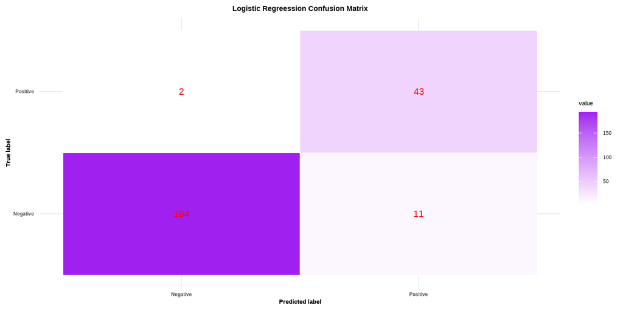

```r
#load required packages
library(reshape2)
library(scales)

# Create the confusion matrix
conf_matrix <- matrix(c(194, 11, 2, 43), nrow = 2, byrow = TRUE)

# Name the rows and columns
rownames(conf_matrix) <- c("Negative","Positive")
colnames(conf_matrix) <- c("Negative","Positive")

# Melt the matrix for ggplot
conf_df <- melt(conf_matrix)

# Plot
ggplot(conf_df, aes(x = Var2, y = Var1, fill = value)) +
  geom_tile(color = "white") +
  geom_text(aes(label = value), color = "red", size = 6) +
  scale_fill_gradient(low = "white", high = "purple") +
  labs(title = "Logistic Regreession Confusion Matrix", x = "Predicted label", y = "True label") +
  theme_minimal() +
  theme(
    plot.title = element_text(hjust = 0.5, face = "bold"),
    axis.title.x = element_text(face = "bold"),
    axis.title.y = element_text(face = "bold"),
    axis.text = element_text(face = "bold"))
```

## Model performance metric for classification **Confusion matrix** : is a performance evaluation tool used for classification models. It shows how well the model’s predicted classes match the actual classes.

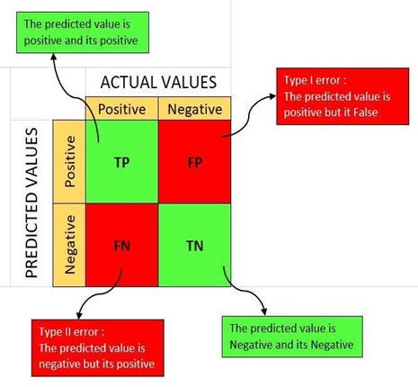

**Accuracy: The proportion of all predictions that are correct** used to determine the performance of the Algorithms

$$\text{Accuracy} = \frac{TP + TN}{TP + FP + FN + TN} =\frac{43 + 194}{43
+ 11 + 2 + 194} = 0.948$$

**Interpretation:**

- How often the classifier is correct overall.

-⚠️ Can be misleading if classes are imbalanced.

**True Positive Rate (TPR): Also known as sensitivity or recall**

- It is the ratio of correctly predicted positive observations to the actual positives.

$$\text{Sensitivity} = \frac{TP}{TP + FN} = 0.956$$

where TP is True Positives and FN is False Negatives.

**Interpretation:**

- Of all the true positive cases, how many did the model catch?
- 📌 Important in medical diagnosis, fraud detection.

$$\text{Specificity} = \frac{TN}{TN + FP} = 0.946$$

where FP is False Positives and TN is True Negatives.

**Interpretation:**

- Of all the true negative cases, how many did the model correctly identify?
- 📌 Important to minimize false alarms.

**Precision: The proportion of predicted positives that are actually positive**

used to test the correctness of the model when it gives a positive outcome

$$\text{Precision} = \frac{TP}{TP + FP} = 0.796$$

**Interpretation:**

- How trustworthy are the positive predictions?

-📌 Important when false positives are costly (e.g., spam filters, cancer screening, malaria detection).

**F1 score: The harmonic mean of precision and recall. It balances the two when both are important.**

Used to assess the number of variables that are missing in the predictions which are positive target

$$F_1 Score = \frac{2 \cdot \text{Precision} \cdot
\text{Recall}}{\text{Precision} + \text{Recall}} = 0.869$$

**Interpretation:**

- F1 reaches its best value at 1 (perfect precision and recall) and worst at 0.
- 📌 Useful in imbalanced classification tasks.

## Importance of features in a Logistic regression Model

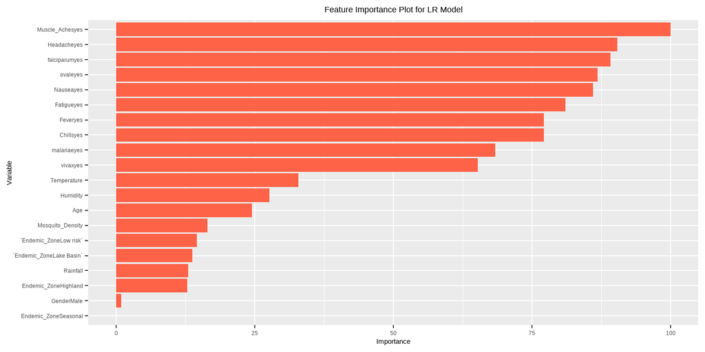

```r
# Show relative importance of features
# vip::vip(LRModel)

# Alternatively using ggplot function
var_imp <-varImp(LRModel)
ggplot(var_imp, aes(x = reorder(Variable, Importance), y = importance)) +
  geom_bar(stat = "identity", fill = "tomato") +
  coord_flip() +
  xlab("Variable") +
  ylab("Importance") +
  ggtitle("Feature Importance Plot for LR Model") +
  theme(plot.title = element_text(hjust = 0.5)) # Align the title to the center
```

## Prepare data for explain() function

```r
library(DALEX)  ## powerful tool for interpreting machine learning models.

# Converts the target variable from categorical ("Positive"/"Negative") to numeric (1=for Positive, 0=otherwise)
# Required for many ML models and for DALEX to interpret the output as binary classification.

train$Malaria_Result <- ifelse(train$Malaria_Result == "Positive", 1, 0)

# Create the explainer Object
explainer_1 <- explain(model = LRModel,
                     data = train[, -which(names(train) =="Malaria_Result")],  # Exclude the target column
                     y = train$Malaria_Result,                                 # Target values as vector
                     label = "Local Explanation with DALEX for Logistics Regression")
```

```
Preparation of a new explainer is initiated
  -> model label       :  Local Explanation with DALEX for Logistics Regression
  -> data              :  750  rows  17  cols
  -> target variable   :  750  values
  -> predict function  :  yhat.train  will be used (  default  )
  -> predicted values  :  No value for predict function target column. (  default  )
  -> model_info        :  package caret , ver. 7.0.1 , task classification (  default  )
  -> predicted values  :  numerical, min =  1.761836e-08 , mean =  0.2061251 , max =  0.9999998
  -> residual function :  difference between y and yhat (  default  )
  -> residuals         :  numerical, min =  -0.9989722 , mean =  -0.02612506 , max =  0.8216142
  A new explainer has been created!
```

```r
# This creates an explainer1 object used by the DALEX and ingredients packages for interpretability methods
```

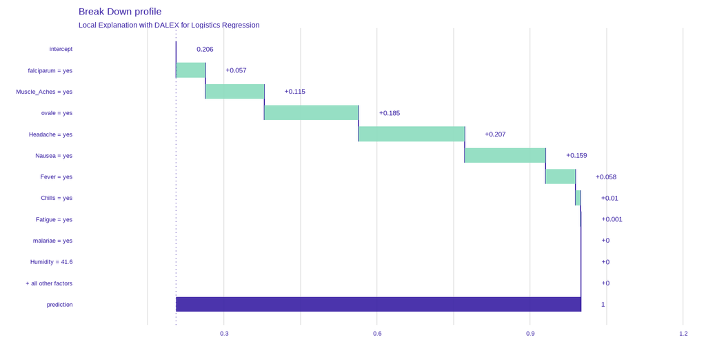

```r
# Select an instance to explain from test set or new unseen data

set.seed(123)
new_observation_1 <- test[3, -which(names(test)=="Malaria_Result")]  # Select a test instance
#new_observation_1

# Break Down explanation for the instance
local_explanation_1 <- predict_parts(explainer_1, new_observation_1)

# Plot local explanation
plot(local_explanation_1)
```

## Breakdown of Contributions

• Predictor Variables: Each predictor variable’s contribution is shown as a bar. The color indicates the direction of the contribution:

• Green: Positive contribution, meaning the variable increases the prediction.

• Red: Negative contribution, meaning the variable decreases the prediction.

• The length of the bar represents the magnitude of the contribution.

## Overall Prediction

However, it is essential to consider the limitations and interpret the results in conjunction with other model evaluation metrics

## SHAP(SHapley Additive exPlanations)

The Shapley value helps explain how much each feature contributes to the prediction made by a machine learning model. It provides a way to fairly distribute the “credit” for the model’s output across all input features. By visualizing the SHAP plot, you can understand not only which features are important, but also how specific feature values that are driving predictions for individual cases.

## SHAP explanation

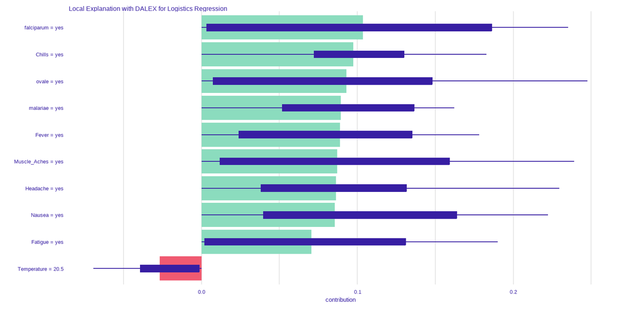

```r
shap_values_1 <- predict_parts(explainer_1, new_observation_1, type = "shap")

plot(shap_values_1)
```

## Overview

1. Leftward(negative): Indicates the feature is pushing the model prediction towards a negative class
2. Larger absolute SHAP values mean a feature has a stronger influence on the prediction.
3. Smaller SHAP values (close to zero) indicate that a feature has minimal influence on the model’s output for that instance

## Partial Dependence Plots (PDP)

- Understand the relationship between features and predictions.
- Visualizes the relationship between features and the target prediction
- Understand non-linear relationships

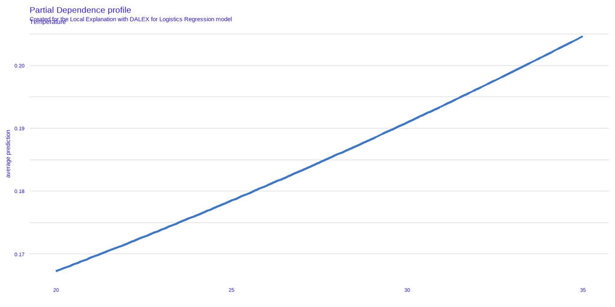

```r
## Partial Dependence Plot for Temperature

pdp <- model_profile(explainer_1, variables = "Temperature", type = "partial")
plot(pdp)
```

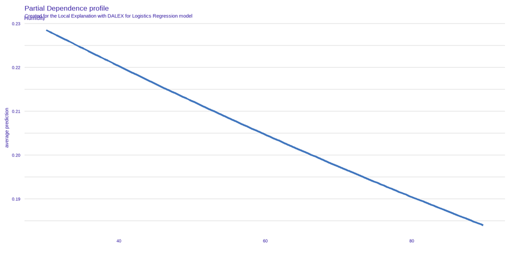

```r
## Partial Dependence Plot for Humidity

pdp <- model_profile(explainer_1, variables = "Humidity", type = "partial")
plot(pdp)
```

# Random Forest

```r
# Load libraries
library(caret)

set.seed(123)
tuneGrid_rf <- expand.grid(mtry = c(2, 4, 6, 8, 12))

tic()
RFModel <- train(factor(Malaria_Result)~.,
                 data=over,
                 method="rf",
                 trControl=control,
                 tuneGrid=tuneGrid_rf)
toc()
```

```
135.41 sec elapsed
```

```r
RFModel
```

```
Random Forest

1230 samples
  17 predictor
   2 classes: 'Negative', 'Positive'

No pre-processing
Resampling: Cross-Validated (10 fold, repeated 5 times)
Summary of sample sizes: 1106, 1106, 1108, 1107, 1107, 1108, ...
Resampling results across tuning parameters:

  mtry  ROC        Sens       Spec
   2    0.9997999  0.9873189  0.9960814
   4    0.9997238  0.9860286  0.9957589
   6    0.9997054  0.9821364  0.9957641
   8    0.9995599  0.9772607  0.9957589
  12    0.9993606  0.9701111  0.9957589

ROC was used to select the optimal model using the largest value.
The final value used for the model was mtry = 2.
```

```r
#plot(RFModel)
```

## Prediction & Evaluation of the RF model performance metrics

```r
# Prediction using RF model
RFpred=predict(RFModel,newdata = test)

# Evaluation of the RF model performance metrics
RF_CM<- confusionMatrix(RFpred,as.factor(test$Malaria_Result), positive = "Positive", mode='everything')
RF_CM
```

```
Confusion Matrix and Statistics

          Reference
Prediction Negative Positive
  Negative      201        5
  Positive        4       40

               Accuracy : 0.964
                 95% CI : (0.9328, 0.9834)
    No Information Rate : 0.82
    P-Value [Acc > NIR] : 3.662e-12

                  Kappa : 0.877

 Mcnemar's Test P-Value : 1

            Sensitivity : 0.8889
            Specificity : 0.9805
         Pos Pred Value : 0.9091
         Neg Pred Value : 0.9757
              Precision : 0.9091
                 Recall : 0.8889
                     F1 : 0.8989
             Prevalence : 0.1800
         Detection Rate : 0.1600
   Detection Prevalence : 0.1760
      Balanced Accuracy : 0.9347

       'Positive' Class : Positive
```

## Plot of Confusion Matrix of Random Forest

[figure not shown]

```r
#load required packages
library(reshape2)
library(scales)

# Create the confusion matrix
conf_matrix <- matrix(c(201, 5, 4, 40), nrow = 2, byrow = TRUE)

# Name the rows and columns
rownames(conf_matrix) <- c("Negative","Positive")
colnames(conf_matrix) <- c("Negative","Positive")

# Melt the matrix for ggplot
conf_df <- melt(conf_matrix)

# Plot
ggplot(conf_df, aes(x = Var2, y = Var1, fill = value)) +
  geom_tile(color = "white") +
  geom_text(aes(label = value), color = "black", size = 6) +
  scale_fill_gradient(low = "white", high = "purple") +
  labs(title = "Random Forest Confusion Matrix", x = "Predicted label", y = "True label") +
  theme_minimal() +
  theme(
    plot.title = element_text(hjust = 0.5, face = "bold"),
    axis.title.x = element_text(face = "bold"),
    axis.title.y = element_text(face = "bold"),
    axis.text = element_text(face = "bold"))
```

## Importance of features in a Random Model

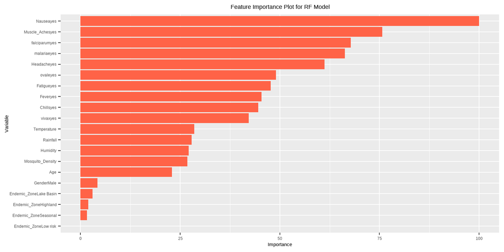

```r
# Show relative importance of features
# vip::vip(RFModel)

# Alternatively using ggplot function
var_imp <-varImp(RFModel)
ggplot(var_imp, aes(x = reorder(Variable, Importance), y = importance)) +
  geom_bar(stat = "identity", fill = "tomato") +
  coord_flip() +
  xlab("Variable") +
  ylab("Importance") +
  ggtitle("Feature Importance Plot for RF Model") +
  theme(plot.title = element_text(hjust = 0.5)) # Align the title to the center
```

## Prepare data for explain() function

```r
library(DALEX)

# Converts the target variable from categorical ("Positive"/"Negative") to numeric (1 for Positive, 0 otherwise)
# Required for many ML models and for DALEX to interpret the output as binary classification.

train$Malaria_Result <- ifelse(train$Malaria_Result == "Positive", 1, 0)

# Create the explainer Object
explainer_2 <- explain(model = RFModel,
                     data = train[, -which(names(train) =="Malaria_Result")],  # Exclude the target column
                     y = train$Malaria_Result,                                 # Target values as vector
                     label = "Local Explanation with DALEX for Random Forest")
```

```
Preparation of a new explainer is initiated
  -> model label       :  Local Explanation with DALEX for Random Forest
  -> data              :  750  rows  17  cols
  -> target variable   :  750  values
  -> predict function  :  yhat.train  will be used (  default  )
  -> predicted values  :  No value for predict function target column. (  default  )
  -> model_info        :  package caret , ver. 7.0.1 , task classification (  default  )
  -> predicted values  :  numerical, min =  0 , mean =  0.2224133 , max =  1
  -> residual function :  difference between y and yhat (  default  )
  -> residuals         :  numerical, min =  -1 , mean =  -0.2224133 , max =  0
  A new explainer has been created!
```

```r
# This creates an explainer object used by the DALEX and ingredients packages for interpretability methods
```

```r
# Select an instance to explain
new_observation_2 <- test[3, -which(names(test)=="Malaria_Result")]  # Select a test instance
new_observation_2
```

```
  Age Gender Rainfall Temperature Humidity Endemic_Zone Mosquito_Density Fever
4  40 Female    145.8        20.5     41.6   Lake Basin             72.3   yes
  Chills Headache Nausea Muscle_Aches Fatigue falciparum vivax malariae ovale
4    yes      yes    yes          yes     yes        yes    no      yes   yes
```

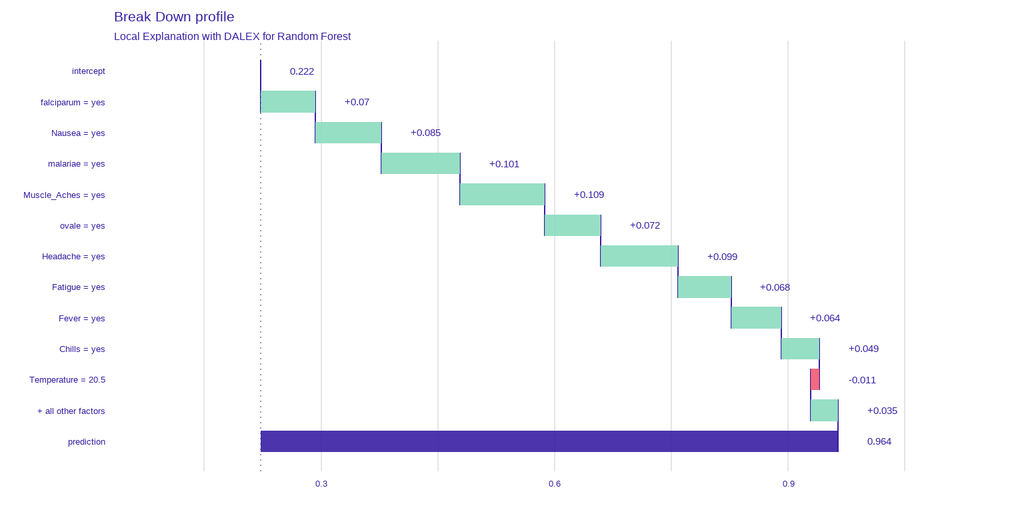

```r
# Break Down explanation for the instance
local_explanation_2 <- predict_parts(explainer_2, new_observation_2)

# Plot local explanation
plot(local_explanation_2)
```

## Breakdown of Contributions

• Predictor Variables: Each predictor variable’s contribution is shown as a bar. The color indicates the direction of the contribution:

• Green: Positive contribution, meaning the variable increases the prediction.

• Red: Negative contribution, meaning the variable decreases the prediction.

• The length of the bar represents the magnitude of the contribution.

## Overall Prediction

This graph provides a valuable tool for understanding how a RF model arrives at a specific prediction. It highlights the relative importance of different predictor variables and their impact on the final outcome.

However, it is essential to consider the limitations and interpret the results in conjunction with other model evaluation metrics

## SHAP(SHapley Additive exPlanations)

The Shapley value helps explain how much each feature contributes to the prediction made by a machine learning model. It provides a way to fairly distribute the “credit” for the model’s output across all input features. By visualizing the SHAP plot, you can understand not only which features are important, but also how specific feature values that are driving predictions for individual cases.

## SHAP explanation

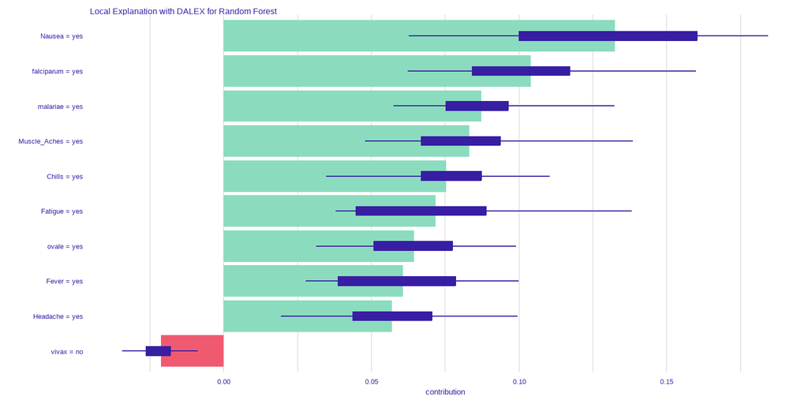

```r
shap_values_2 <- predict_parts(explainer_2, new_observation_2, type = "shap")

plot(shap_values_2)
```

## Overview

1. Leftward(negative): Indicates the feature is pushing the model prediction towards a negative class
2. Larger absolute SHAP values mean a feature has a stronger influence on the prediction.
3. Smaller SHAP values (close to zero) indicate that a feature has minimal influence on the model’s output for that instance

## Partial Dependence Plots (PDP)

- Understand the relationship between features and predictions.
- Visualizes the relationship between features and the target prediction
- Understand non-linear relationships

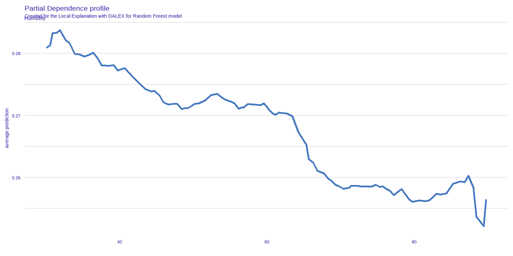

```r
## Partial Dependence Plot for Humidity

pdp <- model_profile(explainer_2, variables = "Humidity", type = "partial")
plot(pdp)
```

## ASSIGNMENT(Try for other Models)

# NB: You can try other models like SVM, KNN, Naive Baiyes, XGBoost, LightGBM, CatBoost, etc. by following the same pattern as above.